# Emission_Canada

Rahmafatin Izza

2023-09-27

Set up environment

# Machine Learning

MAchine learning adalah mesin dapat mempelajari pola data hingga melakukan estimasi/prediksi di masa depan. Secara garis besar machine learning dibagi menjadi dua :

1. **Supervised Learning** : Memiliki variabel target (Nilai yang ingin di prediksi)

**Regression** : Variabel target berupa nilai **numerik** **Classification** : variabel targetnya nilai **kategorik**

2. **Unsupervised Learning** : Tidak memiliki variabel target (Hanya mempelajari pola)
- Clustering
- Dimensionality Reduction

## Contoh kasus regresi :

Dalam pemilihan variabel pada kasus regresi, biasanya dikaitkan dengan masalah bisnis yang akan di selesaikan :

1. Seorang pemilik usaha retail ingin membuat beberapa produk baru. Pengusaha tersebut ingin memprediksi berapa kira - kira harga pokok penjualan yang bisa dia tentukan untuk produk tersebut.
- Target : Harga penjualan produk
- Prediktor : Harga bahan, biaya jasa, demand pasar, kualitas bahan produksi.
2. Seorang tim HR dari sebuah perusahaan ingin memprediksi berapa gaji yang bisa diberikan untuk seorang karyawan baru agar tidak ada ketimpangan antar gaji karyawan pada perusahaan tersebut.
- Target : Gaji
- Prediktor : Lama pengalaman, tingkat pendidikan, Usia, Keterampilan khusus.

# Linear Regression

Linear regression adalah salah satu algoritma regresi dalam **Supervised Learning** yang mana variabel target(Y) bernilai **numerik**.

📐 Formula model Linear Regression
$$\hat{y}=\beta_0+\beta_1.x_1+...+\beta_n.x_n$$
Keterangan : * $y$ = Nilai variable target * $\beta_0$ = Intercept, nilai variable target saat seluruh prediktor = 0 (direpresentasikan sebagai titik potong dengan sumbu y) * $\beta_1 ... \beta_n$ = Nilai koefisien variable prediktor * $x_1 ... x_n$ = Nilai variabel prediktor

### Study Case : Emission prediction

Di Indonesia memiliki tingkat polusi yang tinggi. Salah satu polusinya adalah polusi udara. Hal ini bisa dikarenakan emisi karbon. Secara global emisi karbon dihasilkan dari pembakaran bahan bakar fosil yaitu 36% dari industri energi (pembangkit listrik/kilang minyak, dll), 27% dari sektor transportasi, 21% dari sektor industri, 15% dari sektor rumah tangga & jasa, 1% dari sektor lain -lain. Sektor transportasi menjadi penyumbang emisi karbon terbanyak kedua setelah sektor industri energi. Secara umum, nilai Emisi pada kendaraan bermotor dapat dihitung berdasarkan **nilai konsumsi bahan bakar** dan **jenis bahan bakar**. Tetapi pada praktiknya konsumsi bahan bakar juga dipengaruhi oleh gaya berkendara pengguna. Apakah pengguna sering melakukan akselerasi atau pengereman mendadak. Secara umum faktor akselerasi dan pengereman mendadak juga dapat dilihat dari jenis jalanan yang dilewati. Apabila pada jalan tol(Highway), kecepatan cenderung konstan sehingga nilai konsumsi bahan bakar akan lebih rendah dan menyebabkan emisi karbon pada kendaraan tersebut juga rendah.

Dari informasi tersebut, kita akan melakukan analisis apakah emisi hanya disebabkan oleh konsumsi bahan bakar atau beberapa faktor yang lain ?

### Dataset Information

Dataset yang digunakan merupakan dataset https://www.kaggle.com/datasets/debajyotipodder/co2-emission-by-vehicles?select=CO2+Emissions_Canada.csv Dataset ini merupakan dataset yang sudah di transformasi dari dataset asli milik pemerintah Canada yaitu https://open.canada.ca/data/en/dataset/98f1a129-f628-4ce4-b24d-6f16bf24dd64#wb-auto-6.

Dataset ini menujukkan nilai emisi pada kendaraan bermotor di canada, khususnya kendaraan roda 4 keatas.

- Make : Perusahaan pembuat kendaraan
- Model : Model kendaraan bermotor 4WD/4X4 = Four-wheel drive AWD = All-wheel drive FFV = Flexible-fuel vehicle SWB = Short wheelbase LWB = Long wheelbase EWB = Extended wheelbase
- Vehicle.Class : kelas kendaraan
- Engine.Size.L : Ukuran mesin dalam Liter
- Cylinders : Banyak silinder kendaraan
- Transmission : Jenis transmisi kendaraan A = automatic AM = automated manual AS = automatic with select shift AV = continuously variable M = manual 3 - 10 = Number of gears
- Fuel.Type : Jenis bahan bakar yang digunakan X = regular gasoline Z = premium gasoline D = diesel E = ethanol (E85) N = natural gas
- Fuel.Consumption.City..L.100.km. : Konsumsi bahan bakar tiap 100km apabila berjalan di jalanan kota
- Fuel.Consumption.Hwy..L.100.km. : Konsumsi bahan bakar tiap 100km apabila berjalan di jalanan tol(highway)
- Fuel.Consumption.Comb..L.100.km. : Konsumsi bahan bakar tiap 100km yang di kombinasikan untuk jalanan kota dan highway ((55% city, 45% hwy))
- Fuel.Consumption.Comb..mpg : Komsumsi bahan bakar dalam satuan miles per gram
- CO2.Emission.g.km. : Emisi karbon kendaraan dalam gram untuk setiap km.

Dari informasi data tersebut kita akan menentukan variabel taget dan melihat bagaimana hubungan tiap variabel terhadap variabel target : * variabel target : CO2.Emission.g.km.

Note : Variabel Consumption.Comb tidak akan digunakan hal ini dikarenakan nilai tersebut merupakan hasil penjumlahan dari 2 variabel yang lain, sehingga untuk mencegah multikolinearitas.

#### Data Preparation

1. **Read data**

```r
library(rmarkdown)
emission <-  read.csv('data/CO2 Emissions_Canada.csv')
paged_table(head(emission))
```

|  | Make | Model | Vehicle.Class | Engine.Size.L. | Cylinders | Transmission | Fuel.Type | Fuel.Consumption.City..L.100.km. | Fuel.Consumption.Hwy..L.100.km. | Fuel.Consumption.Comb..L.100.km. | Fuel.Consumption.Comb..mpg. | CO2.Emissions.g.km. |
| --- | --- | --- | --- | --- | --- | --- | --- | --- | --- | --- | --- | --- |
| 1 | ACURA | ILX | COMPACT | 2.0 | 4 | AS5 | Z | 9.9 | 6.7 | 8.5 | 33 | 196 |
| 2 | ACURA | ILX | COMPACT | 2.4 | 4 | M6 | Z | 11.2 | 7.7 | 9.6 | 29 | 221 |
| 3 | ACURA | ILX HYBRID | COMPACT | 1.5 | 4 | AV7 | Z | 6.0 | 5.8 | 5.9 | 48 | 136 |
| 4 | ACURA | MDX 4WD | SUV - SMALL | 3.5 | 6 | AS6 | Z | 12.7 | 9.1 | 11.1 | 25 | 255 |
| 5 | ACURA | RDX AWD | SUV - SMALL | 3.5 | 6 | AS6 | Z | 12.1 | 8.7 | 10.6 | 27 | 244 |
| 6 | ACURA | RLX | MID-SIZE | 3.5 | 6 | AS6 | Z | 11.9 | 7.7 | 10.0 | 28 | 230 |

2. **Periksa struktur data**

```r
str(emission)
```

```
#> 'data.frame':    7385 obs. of  12 variables:
#>  $ Make                            : chr  "ACURA" "ACURA" "ACURA" "ACURA" ...
#>  $ Model                           : chr  "ILX" "ILX" "ILX HYBRID" "MDX 4WD" ...
#>  $ Vehicle.Class                   : chr  "COMPACT" "COMPACT" "COMPACT" "SUV - SMALL" ...
#>  $ Engine.Size.L.                  : num  2 2.4 1.5 3.5 3.5 3.5 3.5 3.7 3.7 2.4 ...
#>  $ Cylinders                       : int  4 4 4 6 6 6 6 6 6 4 ...
#>  $ Transmission                    : chr  "AS5" "M6" "AV7" "AS6" ...
#>  $ Fuel.Type                       : chr  "Z" "Z" "Z" "Z" ...
#>  $ Fuel.Consumption.City..L.100.km.: num  9.9 11.2 6 12.7 12.1 11.9 11.8 12.8 13.4 10.6 ...
#>  $ Fuel.Consumption.Hwy..L.100.km. : num  6.7 7.7 5.8 9.1 8.7 7.7 8.1 9 9.5 7.5 ...
#>  $ Fuel.Consumption.Comb..L.100.km.: num  8.5 9.6 5.9 11.1 10.6 10 10.1 11.1 11.6 9.2 ...
#>  $ Fuel.Consumption.Comb..mpg.     : int  33 29 48 25 27 28 28 25 24 31 ...
#>  $ CO2.Emissions.g.km.             : int  196 221 136 255 244 230 232 255 267 212 ...
```

```r
summary(emission)
```

```
#>      Make              Model           Vehicle.Class      Engine.Size.L.
#>  Length:7385        Length:7385        Length:7385        Min.   :0.90
#>  Class :character   Class :character   Class :character   1st Qu.:2.00
#>  Mode  :character   Mode  :character   Mode  :character   Median :3.00
#>                                                           Mean   :3.16
#>                                                           3rd Qu.:3.70
#>                                                           Max.   :8.40
#>    Cylinders      Transmission        Fuel.Type
#>  Min.   : 3.000   Length:7385        Length:7385
#>  1st Qu.: 4.000   Class :character   Class :character
#>  Median : 6.000   Mode  :character   Mode  :character
#>  Mean   : 5.615
#>  3rd Qu.: 6.000
#>  Max.   :16.000
#>  Fuel.Consumption.City..L.100.km. Fuel.Consumption.Hwy..L.100.km.
#>  Min.   : 4.20                    Min.   : 4.000
#>  1st Qu.:10.10                    1st Qu.: 7.500
#>  Median :12.10                    Median : 8.700
#>  Mean   :12.56                    Mean   : 9.042
#>  3rd Qu.:14.60                    3rd Qu.:10.200
#>  Max.   :30.60                    Max.   :20.600
#>  Fuel.Consumption.Comb..L.100.km. Fuel.Consumption.Comb..mpg.
#>  Min.   : 4.10                    Min.   :11.00
#>  1st Qu.: 8.90                    1st Qu.:22.00
#>  Median :10.60                    Median :27.00
#>  Mean   :10.98                    Mean   :27.48
#>  3rd Qu.:12.60                    3rd Qu.:32.00
#>  Max.   :26.10                    Max.   :69.00
#>  CO2.Emissions.g.km.
#>  Min.   : 96.0
#>  1st Qu.:208.0
#>  Median :246.0
#>  Mean   :250.6
#>  3rd Qu.:288.0
#>  Max.   :522.0
```

Terdapat data yang memiliki struktur yang kurang tepat, yaitu pada Make, Model, Vehicle class, Transmission, dan Fuel.type Ubah tipe tersebut menjadi factor.

```r
library(dplyr)
```

```r
emission <-
emission %>%
  mutate_if(.predicate = is.character, .funs = as.factor)
```

Data kita sudah memiliki tipe yang sesuai. Maka selanjutnya kita akan melihat apakah terdapat missing value pada data kita.

```r
glimpse(emission)
```

```
#> Rows: 7,385
#> Columns: 12
#> $ Make                             <fct> ACURA, ACURA, ACURA, ACURA, ACURA, AC…
#> $ Model                            <fct> ILX, ILX, ILX HYBRID, MDX 4WD, RDX AW…
#> $ Vehicle.Class                    <fct> COMPACT, COMPACT, COMPACT, SUV - SMAL…
#> $ Engine.Size.L.                   <dbl> 2.0, 2.4, 1.5, 3.5, 3.5, 3.5, 3.5, 3.…
#> $ Cylinders                        <int> 4, 4, 4, 6, 6, 6, 6, 6, 6, 4, 4, 6, 4…
#> $ Transmission                     <fct> AS5, M6, AV7, AS6, AS6, AS6, AS6, AS6…
#> $ Fuel.Type                        <fct> Z, Z, Z, Z, Z, Z, Z, Z, Z, Z, Z, Z, Z…
#> $ Fuel.Consumption.City..L.100.km. <dbl> 9.9, 11.2, 6.0, 12.7, 12.1, 11.9, 11.…
#> $ Fuel.Consumption.Hwy..L.100.km.  <dbl> 6.7, 7.7, 5.8, 9.1, 8.7, 7.7, 8.1, 9.…
#> $ Fuel.Consumption.Comb..L.100.km. <dbl> 8.5, 9.6, 5.9, 11.1, 10.6, 10.0, 10.1…
#> $ Fuel.Consumption.Comb..mpg.      <int> 33, 29, 48, 25, 27, 28, 28, 25, 24, 3…
#> $ CO2.Emissions.g.km.              <int> 196, 221, 136, 255, 244, 230, 232, 25…
```

3. **Missing Value**

```r
anyNA(emission)
```

```
#> [1] FALSE
```

Dari fungsi anyNA() diketahui bahwa pada data kita tidak terdapat missing value. Selanjutnya kita akan masuk ke tahap Exploratory Data Analysis untuk mengetahui informasi apa yang bisa kita dapat dari data kita.

#### Exploratory Data Analysis

1. Distribusi data pda variabel target

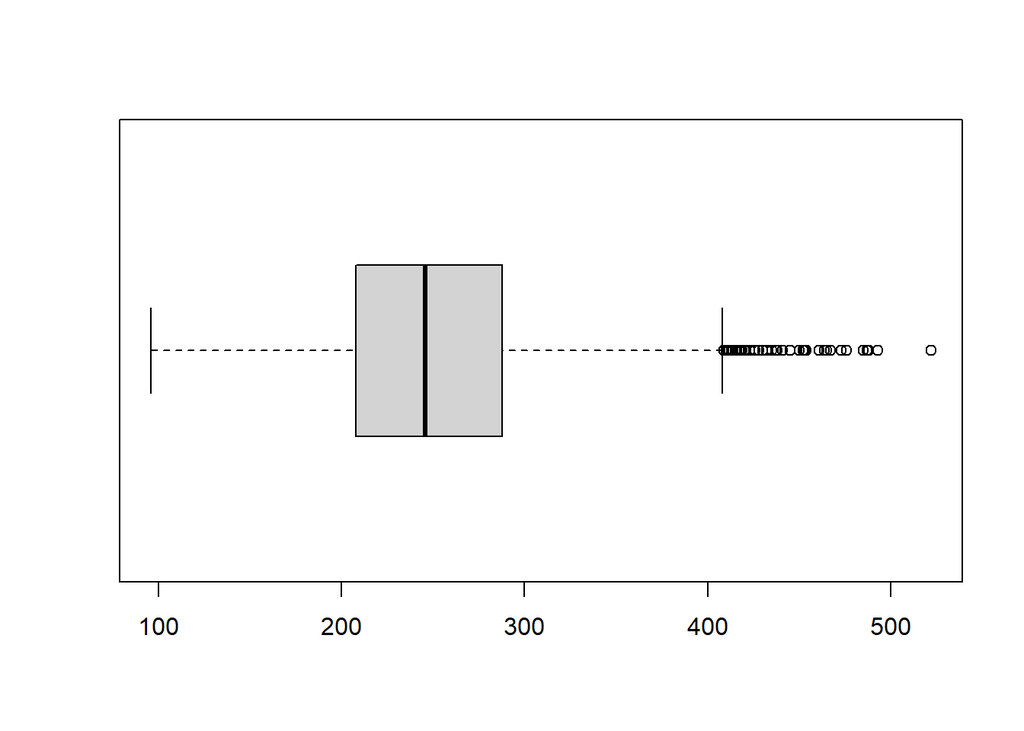

```r
boxplot(emission$CO2.Emissions.g.km., horizontal = T)
```

Dari boxplot diatas didapatkan insight : - Terdapat outlier pada data emisi kita - Nilai outlier tidak begitu ekstrim tetapi frekuensinya cukup banyak.

```r
paged_table(emission[emission$CO2.Emissions.g.km. > 400, ])
```

|  | Make | Model | Vehicle.Class | Engine.Size.L. | Cylinders | Transmission | Fuel.Type | Fuel.Consumption.City..L.100.km. | Fuel.Consumption.Hwy..L.100.km. | Fuel.Consumption.Comb..L.100.km. | Fuel.Consumption.Comb..mpg. | CO2.Emissions.g.km. |
| --- | --- | --- | --- | --- | --- | --- | --- | --- | --- | --- | --- | --- |
| 47 | AUDI | R8 | TWO-SEATER | 4.2 | 8 | M6 | Z | 21.2 | 13.4 | 17.7 | 16 | 407 |
| 49 | AUDI | R8 | TWO-SEATER | 5.2 | 10 | M6 | Z | 21.1 | 13.8 | 17.8 | 16 | 409 |
| 51 | AUDI | R8 SPYDER | TWO-SEATER | 4.2 | 8 | M6 | Z | 21.2 | 13.4 | 17.7 | 16 | 407 |
| 53 | AUDI | R8 SPYDER | TWO-SEATER | 5.2 | 10 | M6 | Z | 21.1 | 13.8 | 17.8 | 16 | 409 |
| 76 | BENTLEY | MULSANNE | MID-SIZE | 6.8 | 8 | AS8 | Z | 22.3 | 14.9 | 19.0 | 15 | 437 |
| 224 | CHEVROLET | EXPRESS 2500 PASSENGER | VAN - PASSENGER | 4.8 | 8 | A6 | X | 21.1 | 14.2 | 18.0 | 16 | 414 |
| 225 | CHEVROLET | EXPRESS 2500 PASSENGER | VAN - PASSENGER | 6.0 | 8 | A6 | X | 21.9 | 15.0 | 18.8 | 15 | 432 |
| 226 | CHEVROLET | EXPRESS 2500 PASSENGER | VAN - PASSENGER | 6.0 | 8 | A6 | E | 30.0 | 20.4 | 25.7 | 11 | 411 |
| 227 | CHEVROLET | EXPRESS 3500 PASSENGER | VAN - PASSENGER | 4.8 | 8 | A6 | X | 21.3 | 14.3 | 18.2 | 16 | 419 |
| 228 | CHEVROLET | EXPRESS 3500 PASSENGER | VAN - PASSENGER | 6.0 | 8 | A6 | X | 22.1 | 15.0 | 18.9 | 15 | 435 |

[output cut: 88 more lines]

```r
summary(emission)
```

```
#>             Make                Model             Vehicle.Class  Engine.Size.L.
#>  FORD         : 628   F-150 FFV    :  32   SUV - SMALL   :1217   Min.   :0.90
#>  CHEVROLET    : 588   F-150 FFV 4X4:  32   MID-SIZE      :1133   1st Qu.:2.00
#>  BMW          : 527   MUSTANG      :  27   COMPACT       :1022   Median :3.00
#>  MERCEDES-BENZ: 419   FOCUS FFV    :  24   SUV - STANDARD: 735   Mean   :3.16
#>  PORSCHE      : 376   F-150        :  20   FULL-SIZE     : 639   3rd Qu.:3.70
#>  TOYOTA       : 330   F-150 4X4    :  20   SUBCOMPACT    : 606   Max.   :8.40
#>  (Other)      :4517   (Other)      :7230   (Other)       :2033
#>    Cylinders       Transmission  Fuel.Type Fuel.Consumption.City..L.100.km.
#>  Min.   : 3.000   AS6    :1324   D: 175    Min.   : 4.20
#>  1st Qu.: 4.000   AS8    :1211   E: 370    1st Qu.:10.10
#>  Median : 6.000   M6     : 901   N:   1    Median :12.10
#>  Mean   : 5.615   A6     : 789   X:3637    Mean   :12.56
#>  3rd Qu.: 6.000   A8     : 490   Z:3202    3rd Qu.:14.60
#>  Max.   :16.000   AM7    : 445             Max.   :30.60
#>                   (Other):2225
#>  Fuel.Consumption.Hwy..L.100.km. Fuel.Consumption.Comb..L.100.km.
#>  Min.   : 4.000                  Min.   : 4.10
#>  1st Qu.: 7.500                  1st Qu.: 8.90
#>  Median : 8.700                  Median :10.60
#>  Mean   : 9.042                  Mean   :10.98
#>  3rd Qu.:10.200                  3rd Qu.:12.60
#>  Max.   :20.600                  Max.   :26.10
#>
#>  Fuel.Consumption.Comb..mpg. CO2.Emissions.g.km.
#>  Min.   :11.00               Min.   : 96.0
#>  1st Qu.:22.00               1st Qu.:208.0
#>  Median :27.00               Median :246.0
#>  Mean   :27.48               Mean   :250.6
#>  3rd Qu.:32.00               3rd Qu.:288.0
#>  Max.   :69.00               Max.   :522.0
#>
```

```r
emission_feature <- emission[, c("Make","Model","Vehicle.Class","Engine.Size.L.", "Cylinders","Transmission","Fuel.Type","Fuel.Consumption.City..L.100.km.", "Fuel.Consumption.Hwy..L.100.km.", "CO2.Emissions.g.km.")]
```

```r
library(stringr)

emission_feature <-
emission_feature %>%
  mutate(Transmission_type = str_sub(Transmission, start = 1, end = -2)) %>%
  mutate(Transmission_type = str_replace(Transmission_type, "A1", "A")) %>%
  mutate(Transmission_type = str_replace(Transmission_type, "AS1", "AS")) %>%
  mutate(Transmission_type = str_replace(Transmission_type, "AV1", "AV")) %>%
  mutate(Transmission_type = as.factor(Transmission_type))
```

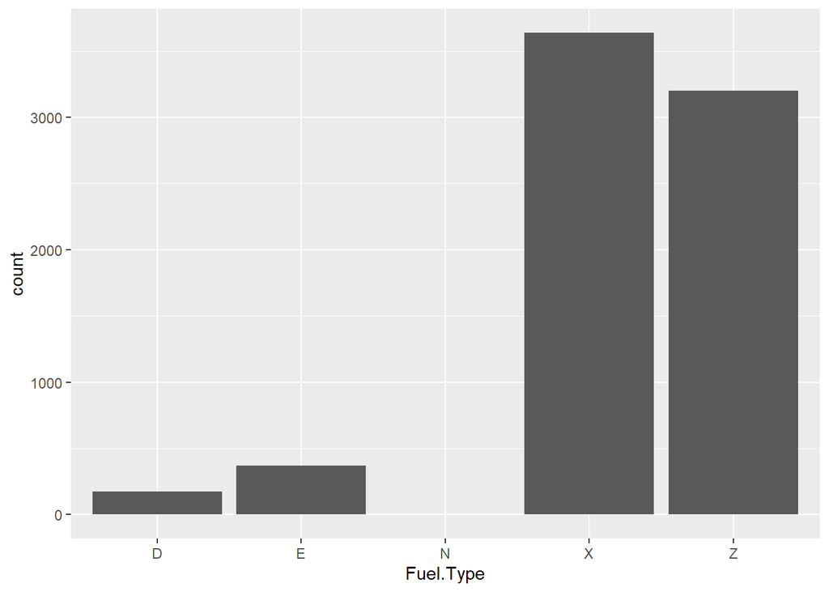

```r
library(ggplot2)

ggplot(data = emission_feature , aes(x=Fuel.Type))+
  geom_bar()
```

Selanjutnya kita akan melihat apakah terdapat outlier pada konsumsi bahan bakar

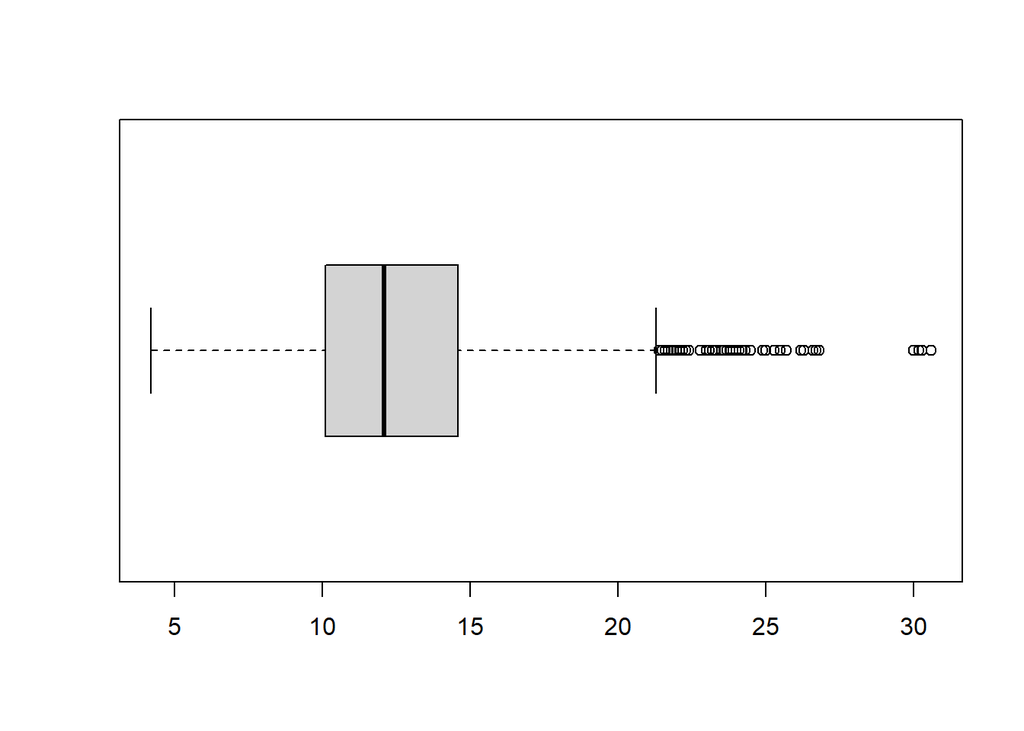

```r
boxplot(emission_feature$Fuel.Consumption.City..L.100.km., horizontal = T)
```

Dapat dilihat bahwa terdapat outlier pada data konsumsi bahan bakar, yaitu sekitar >21.

```r
paged_table(emission_feature[emission_feature$Fuel.Consumption.City..L.100.km. > 21 & emission_feature$CO2.Emissions.g.km. > 400, ])
```

|  | Make | Model | Vehicle.Class | Engine.Size.L. | Cylinders | Transmission | Fuel.Type | Fuel.Consumption.City..L.100.km. | Fuel.Consumption.Hwy..L.100.km. | CO2.Emissions.g.km. | Transmission_type |
| --- | --- | --- | --- | --- | --- | --- | --- | --- | --- | --- | --- |
| 47 | AUDI | R8 | TWO-SEATER | 4.2 | 8 | M6 | Z | 21.2 | 13.4 | 407 | M |
| 49 | AUDI | R8 | TWO-SEATER | 5.2 | 10 | M6 | Z | 21.1 | 13.8 | 409 | M |
| 51 | AUDI | R8 SPYDER | TWO-SEATER | 4.2 | 8 | M6 | Z | 21.2 | 13.4 | 407 | M |
| 53 | AUDI | R8 SPYDER | TWO-SEATER | 5.2 | 10 | M6 | Z | 21.1 | 13.8 | 409 | M |
| 76 | BENTLEY | MULSANNE | MID-SIZE | 6.8 | 8 | AS8 | Z | 22.3 | 14.9 | 437 | AS |
| 224 | CHEVROLET | EXPRESS 2500 PASSENGER | VAN - PASSENGER | 4.8 | 8 | A6 | X | 21.1 | 14.2 | 414 | A |
| 225 | CHEVROLET | EXPRESS 2500 PASSENGER | VAN - PASSENGER | 6.0 | 8 | A6 | X | 21.9 | 15.0 | 432 | A |
| 226 | CHEVROLET | EXPRESS 2500 PASSENGER | VAN - PASSENGER | 6.0 | 8 | A6 | E | 30.0 | 20.4 | 411 | A |
| 227 | CHEVROLET | EXPRESS 3500 PASSENGER | VAN - PASSENGER | 4.8 | 8 | A6 | X | 21.3 | 14.3 | 419 | A |
| 228 | CHEVROLET | EXPRESS 3500 PASSENGER | VAN - PASSENGER | 6.0 | 8 | A6 | X | 22.1 | 15.0 | 435 | A |

[output cut: 59 more lines]

Hubungan linier variabel consumption.city dengan emission

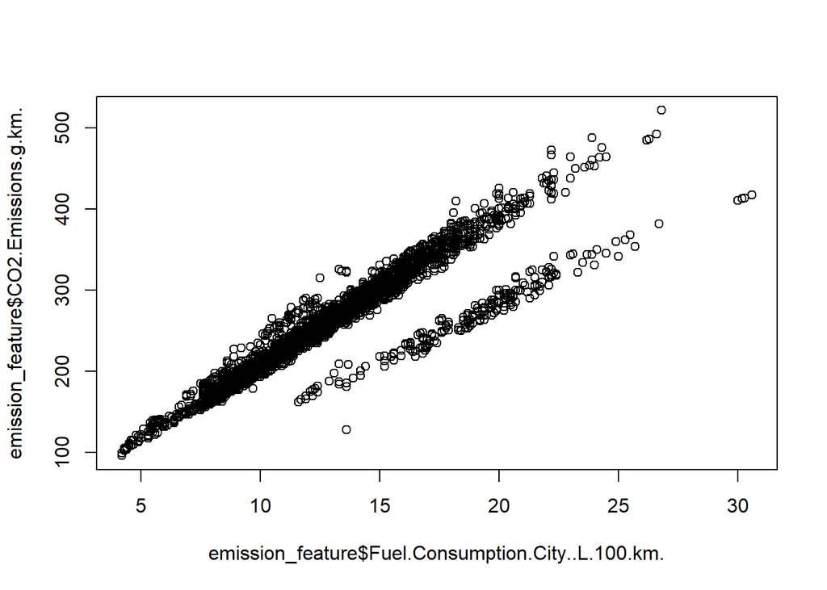

```r
plot(emission_feature$Fuel.Consumption.City..L.100.km. , emission_feature$CO2.Emissions.g.km.)
```

Dapat dilihat bahwa kedua variabel memiliki hubungan yang linear. Hal ini sesuai dengan definisi emisi karbon pada kendaraan bermotor, yaitu apabila konsumsi bahan bakar meningkat maka emisi karbon juga meningkat.

Selanjutnya mari melihat korelasi kedua variabel yang akan digunakan

```r
cor(emission_feature$Fuel.Consumption.City..L.100.km., emission_feature$CO2.Emissions.g.km.)
```

```
#> [1] 0.9195925
```

Kedua variabel memiliki korelasi positif kuat.

## Modelling

Untuk melakukan pemodelan linear regression menggunakan fungsi `lm()`

- Tanpa prediktor: `formula = target ~ 1`
- Satu prediktor: `formula = terget ~ prediktor`
- Beberapa prediktor: `formula = target ~ prediktor1 + prediktor2 + prediktor3`
- Semua prediktor: `formula = target ~ .`
- Exclude prediktor: `formula = target ~ . - ex_prediktor1 - ex_prediktor2`

### Simple Linear Regression

Simple Linear Regression adalah model regresi yang memiliki satu prediktor saja.

📐 Formula Simple Linear Regression :
$$y
= \beta_0 + \beta_1 x$$

Untuk pemodelan pertama kita akan membuat model regresi sederhana dengan prediktor konsumsi bahan bakar pada jalanan kota. yang kita beri nama model_city.

```r
model_city <- lm(formula = CO2.Emissions.g.km. ~ Fuel.Consumption.City..L.100.km. , data = emission_feature)
summary(model_city)
```

```
#>
#> Call:
#> lm(formula = CO2.Emissions.g.km. ~ Fuel.Consumption.City..L.100.km.,
#>     data = emission_feature)
#>
#> Residuals:
#>      Min       1Q   Median       3Q      Max
#> -138.625   -7.045    1.673   11.524   74.172
#>
#> Coefficients:
#>                                  Estimate Std. Error t value
#> (Intercept)                      57.55990    0.99633   57.77
#> Fuel.Consumption.City..L.100.km. 15.37246    0.07643  201.12
#>                                             Pr(>|t|)
#> (Intercept)                      <0.0000000000000002 ***
#> Fuel.Consumption.City..L.100.km. <0.0000000000000002 ***
#> ---
#> Signif. codes:  0 '***' 0.001 '**' 0.01 '*' 0.05 '.' 0.1 ' ' 1
#>
#> Residual standard error: 22.99 on 7383 degrees of freedom
#> Multiple R-squared:  0.8457, Adjusted R-squared:  0.8456
#> F-statistic: 4.045e+04 on 1 and 7383 DF,  p-value: < 0.00000000000000022
```

### Interpretasi Model

Informasi yang bisa didapatkan dari model tersebut :

Dari keterangan diatas didapatkan informasi bahwa : - Variabel yang dipilih menjelaskan variabel target secara signifikan. - Intercept : Apabila tidak ada konsumsi bahan bakar, kendaraan tersebut masih memiliki nilai emisi sebesar 57 gramCo2 - R Square : - Rsquare : 0.84 = 84% - 84% variansi pada target dapat dijelaskan oleh variabel prediktor.

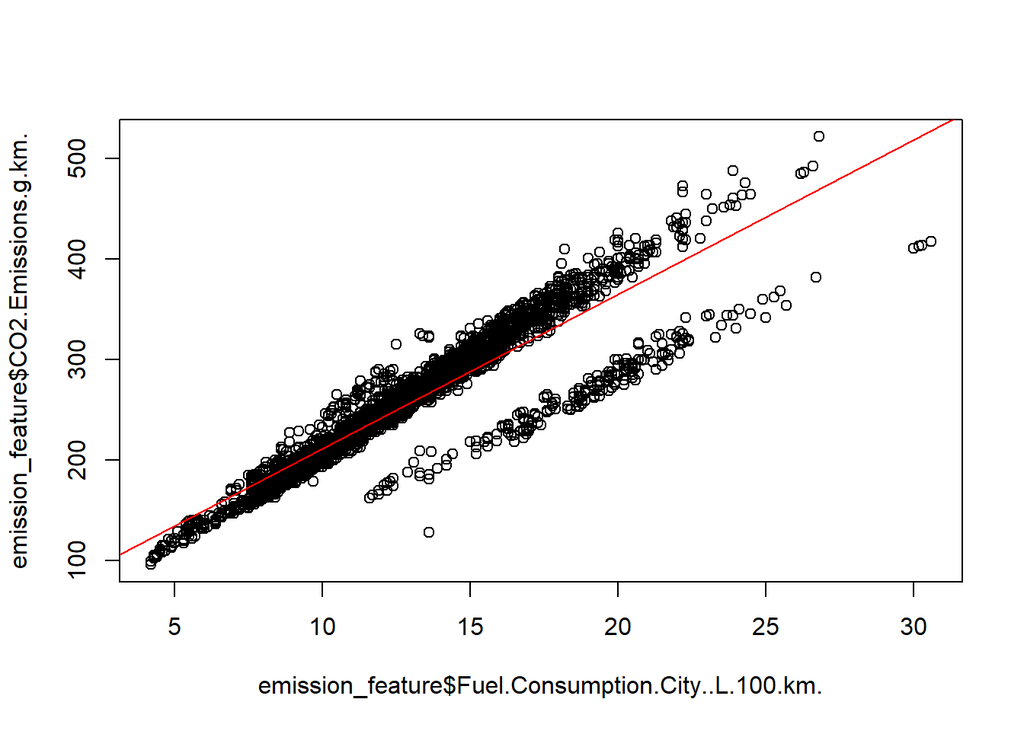

```r
plot(emission_feature$Fuel.Consumption.City..L.100.km. , emission_feature$CO2.Emissions.g.km.)
abline(model_city, col="red")
```

Model linear regression yang kita lakukan memiliki nilai r-square yang relatif tinggi. Tetapi kita akan melakukan analisis menggunakan nilai variabel yang lain.

### Multiple Linear Regression

Multiple linear regression merupakan regresi linear yang memiliki prediktor > 1. Sebagaimana perhitungan nilai emisi pada kendaraan, kita akan mencoba membuat model dengan keseluruhan prediktor.

Note : Kita tidak akan menggunakan variabel Model, Make, Vehicle.Class dan Transmission

```r
emission_feature <- emission_feature[,c("Engine.Size.L.", "Cylinders", "Fuel.Type", "Fuel.Consumption.City..L.100.km.", "Fuel.Consumption.Hwy..L.100.km.", "Transmission_type", "CO2.Emissions.g.km.")]
```

```r
model_all <- lm(dat = emission_feature, formula = CO2.Emissions.g.km. ~ . )
```

Pada model_all kita tidak hanya menggunakan variabel numerik, tetapi juga variabel kategorik yaitu pada variabel Fuel.Type dan Transmission_type. Jika diamati pada model_all summary terdapat beberapa variabel baru. Hal ini merupakan penggunaan dummy variabel untuk model regresi linear

#### Dummy Variable

Berikut ilustrasi Dummy variabel pada kolom fuel.type

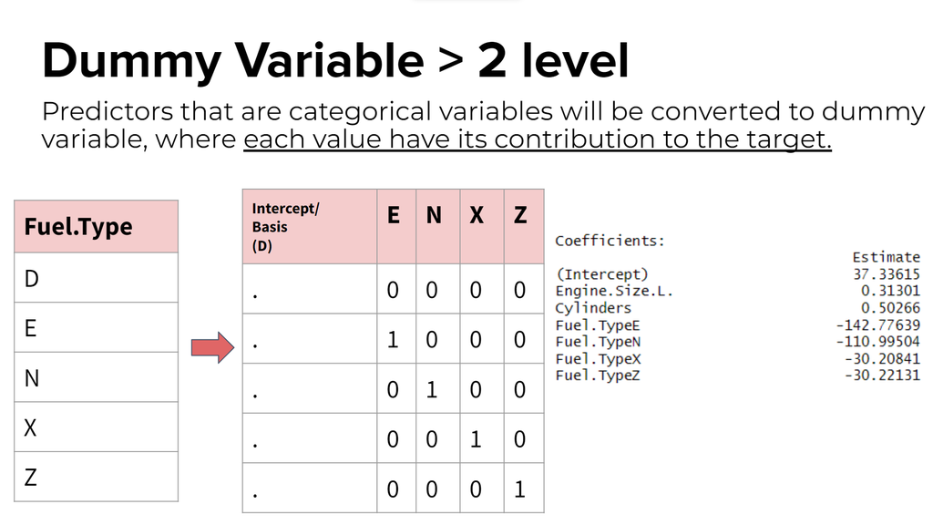

```r
knitr::include_graphics("assets/dummy_var.png")
```

- Akan membentuk sebanyak n-1 variabel.
- Nilai pertama akan menjadi nilai basis/intercept. sehingga tidak ditampilkan
- Representasi nilai untuk variabel fuel.type : Dengan seluruh nilai variabel tetap, maka :
  - Emisi kendaraan akan berkurang sebesar -142.77 saat menggunakan bahan bakar E.
  - Emisi kendaraan akan berkurang sebesar -30.20841 apabila menggunakan bahan bakar X

### Interpretasi Model

```r
summary(model_all)
```

```
#>
#> Call:
#> lm(formula = CO2.Emissions.g.km. ~ ., data = emission_feature)
#>
#> Residuals:
#>     Min      1Q  Median      3Q     Max
#> -64.696  -2.421   0.127   2.202  43.435
#>
#> Coefficients:
#>                                    Estimate Std. Error  t value
#> (Intercept)                        37.33615    0.52320   71.361
#> Engine.Size.L.                      0.31301    0.14278    2.192
#> Cylinders                           0.50266    0.10034    5.009
#> Fuel.TypeE                       -142.77639    0.57629 -247.752
#> Fuel.TypeN                       -110.99504    5.43185  -20.434
#> Fuel.TypeX                        -30.20841    0.42406  -71.237
#> Fuel.TypeZ                        -30.22131    0.43130  -70.070
#> Fuel.Consumption.City..L.100.km.   12.56269    0.07506  167.375
#> Fuel.Consumption.Hwy..L.100.km.     9.60283    0.09523  100.844
#> Transmission_typeAM                 0.16877    0.26181    0.645
#> Transmission_typeAS                 0.33628    0.16071    2.092
#> Transmission_typeAV                -1.29347    0.35862   -3.607
#> Transmission_typeM                 -0.57256    0.21029   -2.723
#>                                              Pr(>|t|)
#> (Intercept)                      < 0.0000000000000002 ***
#> Engine.Size.L.                               0.028393 *
#> Cylinders                                 0.000000559 ***
#> Fuel.TypeE                       < 0.0000000000000002 ***
#> Fuel.TypeN                       < 0.0000000000000002 ***
#> Fuel.TypeX                       < 0.0000000000000002 ***
#> Fuel.TypeZ                       < 0.0000000000000002 ***
#> Fuel.Consumption.City..L.100.km. < 0.0000000000000002 ***
#> Fuel.Consumption.Hwy..L.100.km.  < 0.0000000000000002 ***
#> Transmission_typeAM                          0.519184
#> Transmission_typeAS                          0.036429 *
#> Transmission_typeAV                          0.000312 ***
#> Transmission_typeM                           0.006491 **
#> ---
#> Signif. codes:  0 '***' 0.001 '**' 0.01 '*' 0.05 '.' 0.1 ' ' 1
#>
#> Residual standard error: 5.413 on 7372 degrees of freedom
#> Multiple R-squared:  0.9915, Adjusted R-squared:  0.9914
#> F-statistic: 7.129e+04 on 12 and 7372 DF,  p-value: < 0.00000000000000022
```

💡 Interpretasi model : - Nilai adj r-square : 0.9914 = 99% - 99% variansi target variabel dapat dijelasikan oleh prediktor yang dipilih. - Secara garis besar, keseluruhan prediktor signifikan terhadap target.

### R-Squared vs Adj.R-Squared (Goodness of fit)

**R-squared** adalah ukuran seberapa baik model kita menjelaskan variansi target. Karakteristik r-square : - Berada pada rentang 0 - 1 - Tidak ada aturan baku tentang besar r-square, Hal ini kembali ke urgensi bisnis.

Semakin banyak variabel prediktor yang digunakan, nilai Multiple R-squared meningkat. Terlepas dari apakah nilai variabel tersebut berpengaruh signifikan atau tidak.

**Adjusted R-Square** adalah Nilai r-squared yang disesuaikan dengan jumlah variabel prediktor yang digunakan (faktor penalisasi). Sehingga Adjusted R-Square hanya akan meningkat apabila prediktor yang digunakan memang menghasilkan eror yang lebih kecil.

Penggunaan informasi r-square : **Multiple R-square** : digunakan saat prediktor = 1 **Adjusted R-Square** : digunakan saat prediktor > 1

```r
mean(model_all$fitted.values)
```

```
#> [1] 250.5847
```

```r
mean(emission_feature$CO2.Emissions.g.km.)
```

```
#> [1] 250.5847
```

### Feature Selection

Hal yang harus diperhatikan dalam membuat model machine learning adalah pemilihan variabel target dan prediktor. Prediktor yang kurang tepat bisa jadi memberikan efek yang kurang baik terhadap model kita. Cara pemilihan variabel prediktor : - Berdasarkan bisnis - Berdasarkan statistik : + Korelasi dengan variabel target + Step-wise regression

Pada sebelumnya kita telah membuat dua model yaitu `model_city` dan `model_all` selanjutnya kita akan membuat model dengan prediktor sesuai dengan feature selection

**Correlation** Kita akan membuat model dengan variabel prediktor yang memiliki korelasi tinggi dengan variabel target

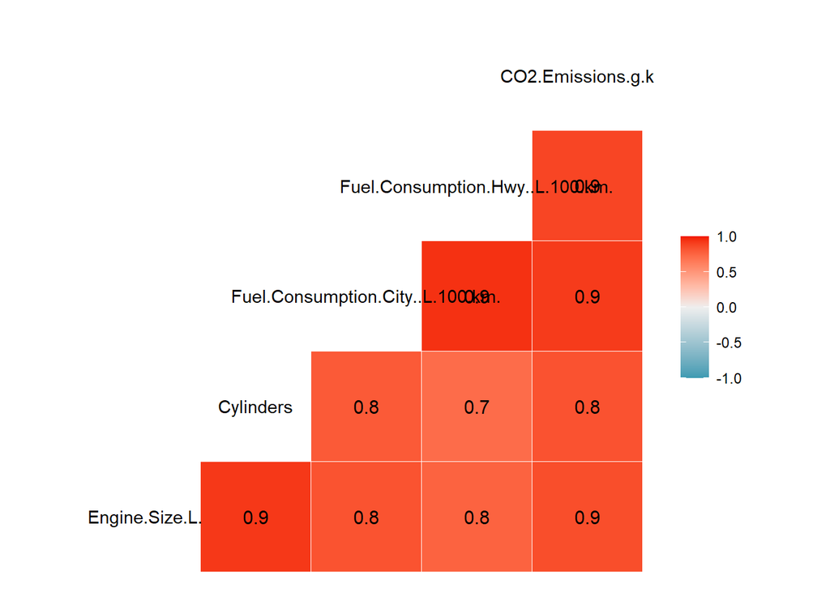

```r
#Cek Korelasi variabel

library(GGally)
ggcorr(emission_feature, label=T)
```

💡Insight : Variabel yang memiliki nilai korelasi tinggi : - Engine.Size - Cylinders - Fuel.Consumption(hwy/city)

```r
model_co2_corr <- lm(data = emission_feature, formula = CO2.Emissions.g.km. ~ Engine.Size.L. + Cylinders + Fuel.Consumption.City..L.100.km. + Fuel.Consumption.Hwy..L.100.km.)
```

```r
summary(model_co2_corr)
```

```
#>
#> Call:
#> lm(formula = CO2.Emissions.g.km. ~ Engine.Size.L. + Cylinders +
#>     Fuel.Consumption.City..L.100.km. + Fuel.Consumption.Hwy..L.100.km.,
#>     data = emission_feature)
#>
#> Residuals:
#>      Min       1Q   Median       3Q      Max
#> -119.016   -6.592    1.883   10.599   72.940
#>
#> Coefficients:
#>                                  Estimate Std. Error t value
#> (Intercept)                       50.8160     1.1799   43.07
#> Engine.Size.L.                     5.5262     0.5106   10.82
#> Cylinders                          6.5339     0.3564   18.34
#> Fuel.Consumption.City..L.100.km.   7.0950     0.2580   27.50
#> Fuel.Consumption.Hwy..L.100.km.    6.2520     0.3448   18.14
#>                                             Pr(>|t|)
#> (Intercept)                      <0.0000000000000002 ***
#> Engine.Size.L.                   <0.0000000000000002 ***
#> Cylinders                        <0.0000000000000002 ***
#> Fuel.Consumption.City..L.100.km. <0.0000000000000002 ***
#> Fuel.Consumption.Hwy..L.100.km.  <0.0000000000000002 ***
#> ---
#> Signif. codes:  0 '***' 0.001 '**' 0.01 '*' 0.05 '.' 0.1 ' ' 1
#>
#> Residual standard error: 20.35 on 7380 degrees of freedom
#> Multiple R-squared:  0.8791, Adjusted R-squared:  0.8791
#> F-statistic: 1.342e+04 on 4 and 7380 DF,  p-value: < 0.00000000000000022
```

💡Insight : - Nilai r-square(Adj.r.square) : 0.8791

### Step Wise Regression

Step Wise regression adalah salah satu metode pembuatan model regresi yang mencari kombinasi variabel prediktor terbaik berdasarkan nilai AIC (Akaike Information Criterion)

**AIC (Akaike Information Criterion)** menunjukkan banyaknya informasi yang hilang pada model (Information Loss) Model yang terbaik adalah yang memiliki nilai **AIC terkecil**

Step Wise regression : - Backward - Forward - Both

#### Backward

[figure not shown]

Tahapan Backward : 1. Buat model dengan seluruh variabel prediktor 2. Masing - masing variabel **dicoba** untuk di hilangkan, Lalu Hitung AIC 3. Hilangkan skema/percobaan yang memiliki AIC terkecil. 4. Ulangi tahap 2 dan 3 hingga mendapat nilai AIC terkecil

```r
model_backward <-  step(model_all, direction = "backward")
```

```
#> Start:  AIC=24956.4
#> CO2.Emissions.g.km. ~ Engine.Size.L. + Cylinders + Fuel.Type +
#>     Fuel.Consumption.City..L.100.km. + Fuel.Consumption.Hwy..L.100.km. +
#>     Transmission_type
#>
#>                                    Df Sum of Sq     RSS   AIC
#> <none>                                           215997 24956
#> - Engine.Size.L.                    1       141  216138 24959
#> - Cylinders                         1       735  216733 24979
#> - Transmission_type                 4      1148  217145 24988
#> - Fuel.Consumption.Hwy..L.100.km.   1    297961  513958 31356
#> - Fuel.Consumption.City..L.100.km.  1    820813 1036811 36539
#> - Fuel.Type                         4   2750816 2966813 44297
```

#### Forward

[figure not shown]

Tahapan Forward : 1. Buat model tanpa prediktor 2. Masing - masing variabel **dicoba** untuk di tambahkan , Lalu Hitung AIC 3. Hilangkan skema/percobaan yang memiliki AIC terkecil. 4. Ulangi tahap 2 dan 3 hingga mendapat nilai AIC terkecil

```r
model_base <- lm(formula = CO2.Emissions.g.km. ~ 1, data=emission_feature)
model_forward <- step(object = model_base, # model referensi
                      direction = "forward",
                      scope = list(upper = model_all,
                                   lower = model_base) # di case forward, lower ga wajib ditulis
                      )
```

```
#> Start:  AIC=60103.73
#> CO2.Emissions.g.km. ~ 1
#>
#>                                    Df Sum of Sq      RSS   AIC
#> + Fuel.Consumption.City..L.100.km.  1  21378758  3902091 46307
#> + Fuel.Consumption.Hwy..L.100.km.   1  19735135  5545714 48903
#> + Engine.Size.L.                    1  18314641  6966209 50587
#> + Cylinders                         1  17527096  7753754 51378
#> + Fuel.Type                         4   1888452 23392397 59538
#> + Transmission_type                 4   1862692 23418158 59547
#> <none>                                          25280849 60104
#>
#> Step:  AIC=46306.6
#> CO2.Emissions.g.km. ~ Fuel.Consumption.City..L.100.km.
#>
#>                                   Df Sum of Sq     RSS   AIC
#> + Fuel.Type                        4   3374758  527333 31534
#> + Cylinders                        1    653609 3248482 44955
#> + Engine.Size.L.                   1    614168 3287923 45044
#> + Transmission_type                4     42503 3859588 46234
#> + Fuel.Consumption.Hwy..L.100.km.  1     33677 3868414 46245
#> <none>                                         3902091 46307
#>
#> Step:  AIC=31534
#> CO2.Emissions.g.km. ~ Fuel.Consumption.City..L.100.km. + Fuel.Type
#>
#>                                   Df Sum of Sq    RSS   AIC
#> + Fuel.Consumption.Hwy..L.100.km.  1    307162 220172 25086
#> + Transmission_type                4     11236 516098 31383
#> + Cylinders                        1       537 526797 31529
#> <none>                                         527333 31534
#> + Engine.Size.L.                   1         1 527332 31536
#>
#> Step:  AIC=25085.75
#> CO2.Emissions.g.km. ~ Fuel.Consumption.City..L.100.km. + Fuel.Type +
#>     Fuel.Consumption.Hwy..L.100.km.
#>
#>                     Df Sum of Sq    RSS   AIC
#> + Cylinders          1    2938.6 217233 24989
#> + Engine.Size.L.     1    2180.9 217991 25014
```

[output cut: 9 more lines]

```
#> + Engine.Size.L.     1     87.46 217145 24988
#> <none>                           217233 24989
#>
#> Step:  AIC=24959.21
#> CO2.Emissions.g.km. ~ Fuel.Consumption.City..L.100.km. + Fuel.Type +
#>     Fuel.Consumption.Hwy..L.100.km. + Cylinders + Transmission_type
#>
#>                  Df Sum of Sq    RSS   AIC
#> + Engine.Size.L.  1    140.81 215997 24956
#> <none>                        216138 24959
#>
#> Step:  AIC=24956.4
#> CO2.Emissions.g.km. ~ Fuel.Consumption.City..L.100.km. + Fuel.Type +
#>     Fuel.Consumption.Hwy..L.100.km. + Cylinders + Transmission_type +
#>     Engine.Size.L.
```

#### Both

Kombinasi antara backeard dan forward :

1. Buat model dasar (boleh all, boleh none)
2. Masing-masing variable dicoba untuk **ditambahkan atau dihilangkan**, lalu dihitung AIC-nya
3. **Tambahkan atau hilangkan** 1 variable yang akan menghasilnya AIC terkecil
4. Ulangi langkah 2 dan 3
5. Proses berhenti apabila saat **penambahan atau pengurangan** variable malah menghasilkan AIC yang lebih tinggi

```r
model_both <- step(object = model_base,
                   direction = "both",
                   scope = list(upper = model_all)
                   )
```

```
#> Start:  AIC=60103.73
#> CO2.Emissions.g.km. ~ 1
#>
#>                                    Df Sum of Sq      RSS   AIC
#> + Fuel.Consumption.City..L.100.km.  1  21378758  3902091 46307
#> + Fuel.Consumption.Hwy..L.100.km.   1  19735135  5545714 48903
#> + Engine.Size.L.                    1  18314641  6966209 50587
#> + Cylinders                         1  17527096  7753754 51378
#> + Fuel.Type                         4   1888452 23392397 59538
#> + Transmission_type                 4   1862692 23418158 59547
#> <none>                                          25280849 60104
#>
#> Step:  AIC=46306.6
#> CO2.Emissions.g.km. ~ Fuel.Consumption.City..L.100.km.
#>
#>                                    Df Sum of Sq      RSS   AIC
#> + Fuel.Type                         4   3374758   527333 31534
#> + Cylinders                         1    653609  3248482 44955
#> + Engine.Size.L.                    1    614168  3287923 45044
#> + Transmission_type                 4     42503  3859588 46234
#> + Fuel.Consumption.Hwy..L.100.km.   1     33677  3868414 46245
#> <none>                                           3902091 46307
#> - Fuel.Consumption.City..L.100.km.  1  21378758 25280849 60104
#>
#> Step:  AIC=31534
#> CO2.Emissions.g.km. ~ Fuel.Consumption.City..L.100.km. + Fuel.Type
#>
#>                                    Df Sum of Sq      RSS   AIC
#> + Fuel.Consumption.Hwy..L.100.km.   1    307162   220172 25086
#> + Transmission_type                 4     11236   516098 31383
#> + Cylinders                         1       537   526797 31528
#> <none>                                            527333 31534
#> + Engine.Size.L.                    1         1   527332 31536
#> - Fuel.Type                         4   3374758  3902091 46307
#> - Fuel.Consumption.City..L.100.km.  1  22865064 23392397 59538
#>
#> Step:  AIC=25085.75
#> CO2.Emissions.g.km. ~ Fuel.Consumption.City..L.100.km. + Fuel.Type +
#>     Fuel.Consumption.Hwy..L.100.km.
#>
```

[output cut: 33 more lines]

```
#> - Fuel.Type                         4   2825728 3041866 44479
#>
#> Step:  AIC=24956.4
#> CO2.Emissions.g.km. ~ Fuel.Consumption.City..L.100.km. + Fuel.Type +
#>     Fuel.Consumption.Hwy..L.100.km. + Cylinders + Transmission_type +
#>     Engine.Size.L.
#>
#>                                    Df Sum of Sq     RSS   AIC
#> <none>                                           215997 24956
#> - Engine.Size.L.                    1       141  216138 24959
#> - Cylinders                         1       735  216733 24979
#> - Transmission_type                 4      1148  217145 24988
#> - Fuel.Consumption.Hwy..L.100.km.   1    297961  513958 31356
#> - Fuel.Consumption.City..L.100.km.  1    820813 1036811 36539
#> - Fuel.Type                         4   2750816 2966813 44297
```

### Model Comparison

Kita sudah memiliki beberapa model yaitu `model_city`, `model_all`, `model_co2_corr`, `model_backward`, `model_forward`, `model_both`. Selanjutnya kita akan mencari model terbaik dengan membandingkan beberapa model yang sudah kita buat.

1. **R-Squared**

```r
summary(model_city)$r.square
```

```
#> [1] 0.8456503
```

```r
summary(model_all)$adj.r.square
```

```
#> [1] 0.9914422
```

```r
summary(model_co2_corr)$adj.r.square
```

```
#> [1] 0.8790842
```

```r
summary(model_backward)$adj.r.square
```

```
#> [1] 0.9914422
```

```r
summary(model_forward)$adj.r.square
```

```
#> [1] 0.9914422
```

```r
summary(model_both)$adj.r.square
```

```
#> [1] 0.9914422
```

💡Insight : - `model_all` memiliki r-square paling tinggi yaitu 0.991 - `model_all` adalah model yang paling baik menjelaskan variansi variabel target. - Hasil dari step wise regression merupakan model dengan seluruh variabel prediktor.

2. **Evaluation Metrics**

### Model Evaluation

Evaluasi terhadap model dilakukan untuk mengetahui apakah model tersebut sudah cukup baik dilihat dari bagaimana eror/residual prediksi. Model yang baik memiliki nilai eror yang rendah.

### Prediction

Kita akan melihat performa model untuk memprediksi pada data training saja. Untuk melakukan prediksi dengan menggunakan fungsi `predict()`.

```r
co2_pred <- data.frame(actual = emission_feature$CO2.Emissions.g.km.)
co2_pred$model_city <- predict(model_city, emission_feature)
co2_pred$model_all <- predict(model_all, emission_feature)
co2_pred$model_co2_corr <- predict(model_co2_corr, emission_feature)
co2_pred$model_backward <- predict(model_backward, emission_feature)
co2_pred$model_forward <- predict(model_forward, emission_feature)
co2_pred$model_both <- predict(model_both, emission_feature)

head(co2_pred)
```

```
#>   actual model_city model_all model_co2_corr model_backward model_forward
#> 1    196   209.7472  198.7974       200.1330       198.7974      198.7974
#> 2    221   229.7314  223.9481       217.8190       223.9481      223.9481
#> 3    136   149.7947  139.3741       164.0725       139.3741      139.3741
#> 4    255   252.7901  258.4946       256.3609       258.4946      258.4946
#> 5    244   243.5667  247.1158       249.6031       247.1158      247.1158
#> 6    230   240.4922  235.0004       241.9321       235.0004      235.0004
#>   model_both
#> 1   198.7974
#> 2   223.9481
#> 3   139.3741
#> 4   258.4946
#> 5   247.1158
#> 6   235.0004
```

### Eror

Eror/residual pada regresi linear adalah selisih dari nilai prediksi dengan nilai aktualnya

$$eror/residual = prediksi - aktual = \hat
y - y$$

#### Mean Squared Eror

MSE menghitung rata-rata dari kuadrat eror.

📐 Formula
$$MSE = \frac{1}{n} \sum (\hat
y - y)^2$$

📌 Fungsi di r : `MSE()`

```r
library(MLmetrics)
MSE(y_pred = co2_pred$model_city,
    y_true = co2_pred$actual)
```

```
#> [1] 528.3806
```

```r
MSE(y_pred = co2_pred$model_all,
    y_true = co2_pred$actual)
```

```
#> [1] 29.24814
```

```r
MSE(y_pred = co2_pred$model_co2_corr,
    y_true = co2_pred$actual)
```

```
#> [1] 413.7032
```

Karakteristik : - Nilai MSE tidak dapat langsung di interpretasikan karena satuannya kuadrat - Nilai MSE digunakan untuk dibandingkan dengan model lain.

#### Root Mean Squared Error

RMSE merupakan bentuk akar dari nilai MSE. Nilai ini dapat di interpretasikan karena satuannya sama.

$$RMSE = \sqrt{\frac{1}{n} \sum (\hat y -
y)^2}$$

```r
library(MLmetrics)
RMSE(y_pred = co2_pred$model_city,
    y_true = co2_pred$actual)
```

```
#> [1] 22.98653
```

```r
RMSE(y_pred = co2_pred$model_all,
    y_true = co2_pred$actual)
```

```
#> [1] 5.408155
```

```r
RMSE(y_pred = co2_pred$model_co2_corr,
    y_true = co2_pred$actual)
```

```
#> [1] 20.33969
```

Dari keseluruhan model yang memiliki nilai RMSE paling kecil adalah model_all

```r
library(performance)
data.frame(compare_performance(model_city, model_all, model_co2_corr, model_backward, model_forward, model_both))
```

```
#>             Name Model      AIC AIC_wt     AICc AICc_wt      BIC BIC_wt
#> 1     model_city    lm 67266.32   0.00 67266.32    0.00 67287.04   0.00
#> 2      model_all    lm 45916.12   0.25 45916.18    0.25 46012.82   0.25
#> 3 model_co2_corr    lm 65465.45   0.00 65465.46    0.00 65506.89   0.00
#> 4 model_backward    lm 45916.12   0.25 45916.18    0.25 46012.82   0.25
#> 5  model_forward    lm 45916.12   0.25 45916.18    0.25 46012.82   0.25
#> 6     model_both    lm 45916.12   0.25 45916.18    0.25 46012.82   0.25
#>          R2 R2_adjusted      RMSE     Sigma
#> 1 0.8456503   0.8456294 22.986532 22.989645
#> 2 0.9914561   0.9914422  5.408155  5.412921
#> 3 0.8791497   0.8790842 20.339694 20.346583
#> 4 0.9914561   0.9914422  5.408155  5.412921
#> 5 0.9914561   0.9914422  5.408155  5.412921
#> 6 0.9914561   0.9914422  5.408155  5.412921
```

Dari nilai evaluasi didapatkan bahwa model terbaik dengan nilai r-squared terbesar dan RMSE terkecil adalah model_all.

```r
summary(model_all)
```

```
#>
#> Call:
#> lm(formula = CO2.Emissions.g.km. ~ ., data = emission_feature)
#>
#> Residuals:
#>     Min      1Q  Median      3Q     Max
#> -64.696  -2.421   0.127   2.202  43.435
#>
#> Coefficients:
#>                                    Estimate Std. Error  t value
#> (Intercept)                        37.33615    0.52320   71.361
#> Engine.Size.L.                      0.31301    0.14278    2.192
#> Cylinders                           0.50266    0.10034    5.009
#> Fuel.TypeE                       -142.77639    0.57629 -247.752
#> Fuel.TypeN                       -110.99504    5.43185  -20.434
#> Fuel.TypeX                        -30.20841    0.42406  -71.237
#> Fuel.TypeZ                        -30.22131    0.43130  -70.070
#> Fuel.Consumption.City..L.100.km.   12.56269    0.07506  167.375
#> Fuel.Consumption.Hwy..L.100.km.     9.60283    0.09523  100.844
#> Transmission_typeAM                 0.16877    0.26181    0.645
#> Transmission_typeAS                 0.33628    0.16071    2.092
#> Transmission_typeAV                -1.29347    0.35862   -3.607
#> Transmission_typeM                 -0.57256    0.21029   -2.723
#>                                              Pr(>|t|)
#> (Intercept)                      < 0.0000000000000002 ***
#> Engine.Size.L.                               0.028393 *
#> Cylinders                                 0.000000559 ***
#> Fuel.TypeE                       < 0.0000000000000002 ***
#> Fuel.TypeN                       < 0.0000000000000002 ***
#> Fuel.TypeX                       < 0.0000000000000002 ***
#> Fuel.TypeZ                       < 0.0000000000000002 ***
#> Fuel.Consumption.City..L.100.km. < 0.0000000000000002 ***
#> Fuel.Consumption.Hwy..L.100.km.  < 0.0000000000000002 ***
#> Transmission_typeAM                          0.519184
#> Transmission_typeAS                          0.036429 *
#> Transmission_typeAV                          0.000312 ***
#> Transmission_typeM                           0.006491 **
#> ---
#> Signif. codes:  0 '***' 0.001 '**' 0.01 '*' 0.05 '.' 0.1 ' ' 1
#>
#> Residual standard error: 5.413 on 7372 degrees of freedom
#> Multiple R-squared:  0.9915, Adjusted R-squared:  0.9914
#> F-statistic: 7.129e+04 on 12 and 7372 DF,  p-value: < 0.00000000000000022
```

Karena linear Regression merupakan model statistik, maka model tersebut memiliki beberapa asumsi yang perlu dipenuhi agar model menjadi model Best Linear Unbiased Estimate (BLUE).

## Asumsi Linear Regression

Asumsi model linear regression:

1. **Linearity**
2. **Normality** of Residuals
3. **Homoscedasticity** of Residuals
4. **No Multicollinearity**

### Linearity

Asumsi linearity merupakan variabel target dan prediktornya memiliki **hubungan yang linear**.

Pada multiple linear regression, asumsi linearity dapat dilihat dengan melakukan visualisasi residual vs fitted.value(prediksi)

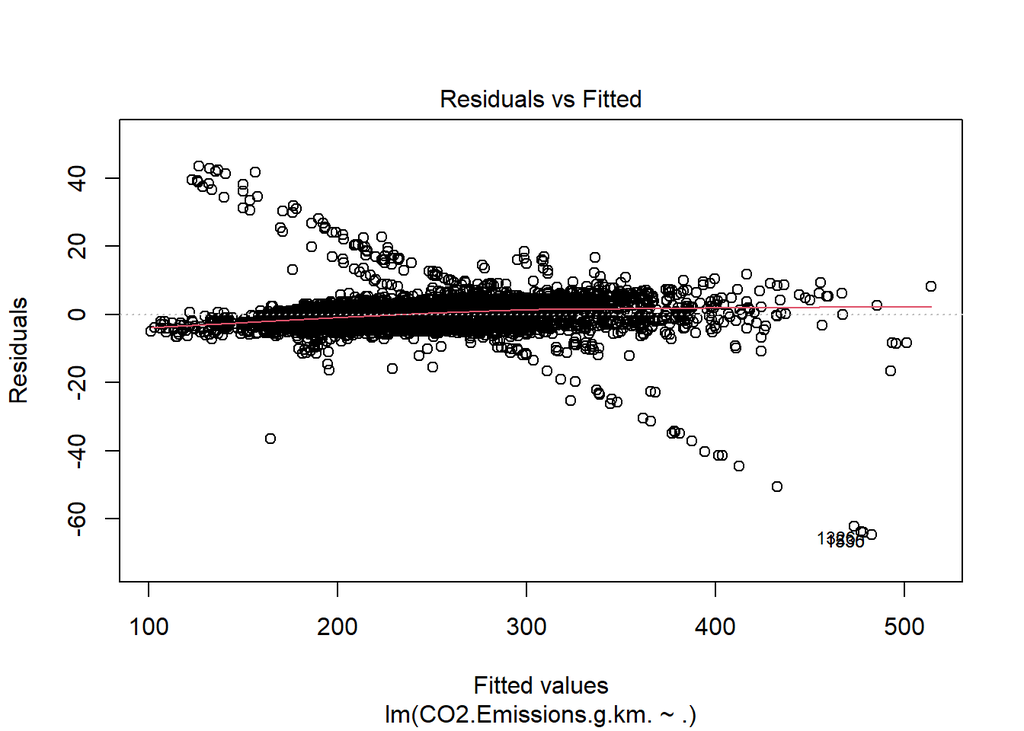

```r
plot(model_all, which = 1)
```

Kondisi yang diharapkan : - Nilai residual **bounce randomly (Menyebar konstan)** di sekitar 0.

**📌 Tambahan**: Apabila ada prediktor yang tidak memenuhi asumsi linearity (dari nilai korelasinya):

1. Tidak perlu dilibatkan di model linear regression
2. Gunakan model lain yang lebih kompleks, sehingga bisa menangkap hubungan non-linear
- Jika data naik turun seperti rumput, dan tidak ada rentang, maka itu bukan hubungan linier. Hal ini dikarenakan hubungan yang linier sendiri artinya perubahan variabel dependen berbanding lurus dengan perubahan variabel independen. Dengan kata lain, harus ada kecenderungan yang jelas dalam data, di mana nilai variabel dependen meningkat atau menurun seiring dengan peningkatan atau penurunan nilai variabel independen.

### Normality of residuals.

Nilai residual.**eror memiliki distribusi normal**.

1. Menggunakan visualisasi `hist()`

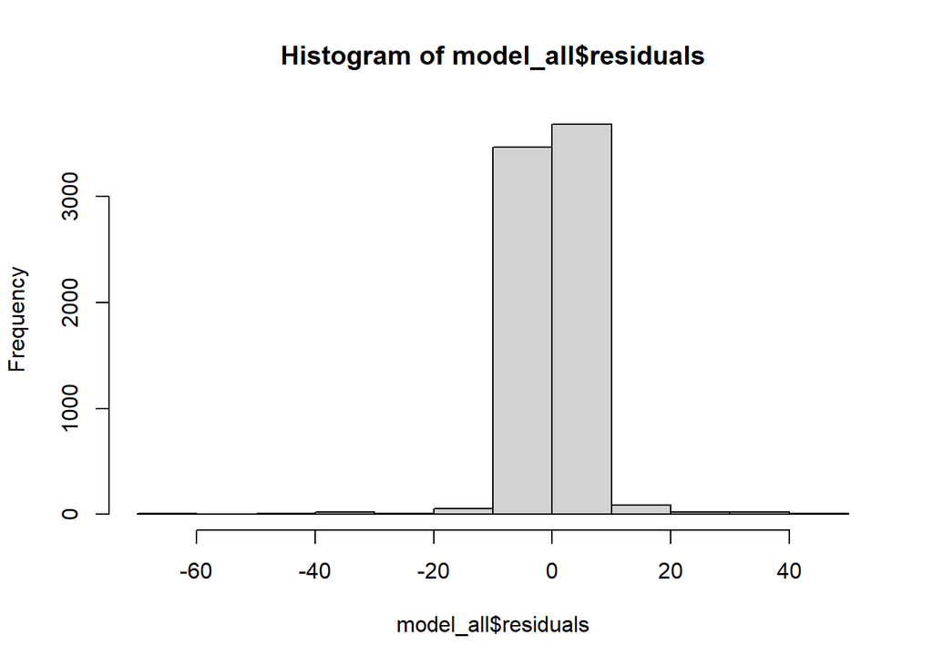

```r
hist(model_all$residuals)
```

- H0: error berdistribusi normal
- H1: error TIDAK berdistribusi normal

```r
# shapiro.test(model_all$residuals)
```

**📌 Tambahan**: Apabila model tidak memenuhi asumsi normality of residual:

1. Handle outlier dengan cara dibuang
2. Lakukan transformasi data pada **variable target** sebelum digunakan di pemodelan, misal dengan fungsi `log()` atau `sqrt()`
3. Gunakan model lain yang lebih kompleks (model yang bebas asumsi)

### Homoscedasticity

Diharapkan error yang dihasilkan oleh model menyebar secara acak atau dengan variasi konstan. Apabila divisualisasikan maka **error tidak berpola** . Kondisi ini disebut juga sebagai **homoscedasticity**

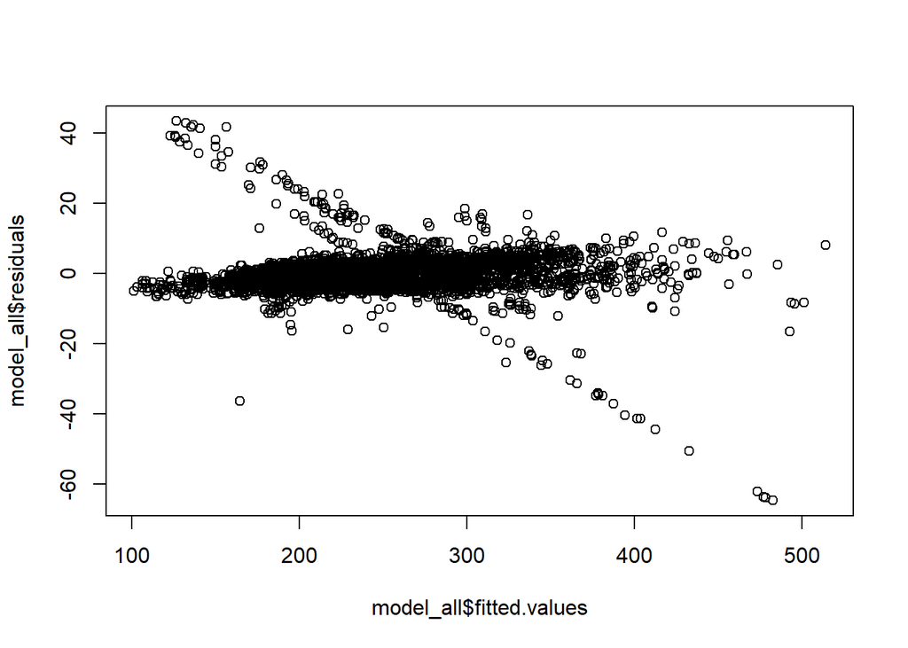

```r
plot(y = model_all$residuals, x=model_all$fitted.values)
```

💡 Dapat dilihat bahwa terdapat satu pola pad grafik residual. Untuk memastikan kita bisa melakukan uji statistik.

2. Uji Statistik dengan `bptest()` dari package `lmtest`

Breuch-Pagan hypothesis test : * H0: error menyebar konstan atau homoscedasticity * H1: error menyebar TIDAK konstan atau heteroscedasticity

```r
library(lmtest)
bptest(model_all)
```

```
#>
#>  studentized Breusch-Pagan test
#>
#> data:  model_all
#> BP = 1733.3, df = 12, p-value < 0.00000000000000022
```

Dengan menggunakan alpha 0.05 > p-value < alpha artinya Tolak H0. -> eror menyebar tidak konstan(Heteroscedasticity)

**📌 Tambahan**: Apabila model tidak memenuhi asumsi homoscedasticity of residual:

1. Lakukan transformasi data pada variable target ataupun predictor sebelum digunakan di pemodelan
2. Gunakan model lain yang lebih kompleks (model yang bebas asumsi)

### No Multicolinearity

Multicolinearity adalah kondisi dimana terdapat **korelasi kuat antar variabel prediktor**.Hal ini tidak diinginkan karena menandakan prediktor redundan pada model, yang seharusnya dapat dipilih salah satu saja dari variable yang hubungannya amat kuat tersebut.

Uji VIF (Variance Inflation Factor) dengan fungsi `vif()` dari package `car`: * nilai VIF > 10: terjadi multicollinearity pada model * nilai VIF < 10: tidak terjadi multicollinearity pada model

```r
library(car)
vif(model_all)
```

```
#>                                       GVIF Df GVIF^(1/(2*Df))
#> Engine.Size.L.                    9.421233  1        3.069403
#> Cylinders                         8.481852  1        2.912362
#> Fuel.Type                         2.238662  4        1.105983
#> Fuel.Consumption.City..L.100.km. 17.394704  1        4.170696
#> Fuel.Consumption.Hwy..L.100.km.  11.307814  1        3.362709
#> Transmission_type                 1.425726  4        1.045333
```

💡 Dari data kita terdapat variabel yang memiliki nilai VIF > 10 yaitu `Fuel.Consumption.Hwy..L.100.km.` dan `Fuel.Consumption.City..L.100.km.` Maka model_all tidak memenuhi asumsi multikolinearity.

Alternatif cara handle:

**📌 Tambahan**: Apabila model tidak memenuhi asumsi no multicollinearity:

1. Membuat model kembali **menggunakan salah satu prediktor** yang terindikasi multiko
2. **Tidak menggunakan prediktor-prediktor** tersebut
3. **Melakukan feature engineering** dengan membuat variabel baru yang berisi rata-rata dari kedua variabel yang terindikasi multiko
4. Gunakan model lain yang lebih kompleks (model yang bebas asumsi)

### Additional r-squared formula

Nilai r-squared bisa di simplifikasi yaitu nilai variance hasil prediksi / variance variabel target.

```r
sum((predict(model_all) - mean(emission_feature$CO2.Emissions.g.km.))**2)/
sum((emission_feature$CO2.Emissions.g.km. - mean(emission_feature$CO2.Emissions.g.km.))**2)
```

```
#> [1] 0.9914561
```

```r
var(predict(model_all))
```

```
#> [1] 3394.482
```

```r
var(emission_feature$CO2.Emissions.g.km.)
```

```
#> [1] 3423.734
```

```r
var(predict(model_all))/
var(emission_feature$CO2.Emissions.g.km.)
```

```
#> [1] 0.9914561
```

Additional Resources https://www.bradthiessen.com/html5/docs/ols.pdf https://online.stat.psu.edu/stat462/node/81/ https://towardsdatascience.com/linear-regression-assumptions-why-is-it-important-af28438a44a1